# project

Evan Pearlman

2025-05-06

# Introduction

Lichess.org is a free, open-source online chess platform where players of all skill levels can compete in games ranging from casual matches to competitive tournaments. To better understand player behavior and game outcomes, a dataset was collected from Lichess containing over 20,000 recorded games. Each record includes detailed information such as player ratings, move sequences, the result of the game, the method of victory (e.g., checkmate, resignation, timeout), and information about the opening moves.

The goal of this project is to discover insights into patterns within chess games, particularly focusing on factors that contribute to winning efficiently. This project will explore the following research questions:

- How does the rating difference between players affect the likelihood of winning?
- What are the most common openings within different rating brackets (e.g., <1400, 1400–1600, 1600–1800)?
- For the most popular openings, what is the distribution of wins, losses, and draws? Are there openings where Black wins more often than White, or vice versa?
- How does the first move & first response influence the outcome of the game?

This data set comes from Lichess.org and can be viewed at https://www.kaggle.com/datasets/datasnaek/chess/data

# Background

Chess is a two-player strategy game that traces back to before 600AD. Each player controls 16 pieces, one controlling black pieces and one white, and the objective is to checkmate the opponent’s king. In competitive chess, players are assigned a *rating*, a numerical value that reflects their skill level based on past performance. Higher ratings indicate stronger players.

An *opening* refers to the sequence of moves played at the start of the game. A game of chess always begins with a move by the player controlling the white pawns. Openings are important because they help players control the board and set up strategies for the middle and endgame.

Chess games can end in various ways, including:

- **Checkmate:** When a king is trapped and cannot escape.
- **Resignation:** When a player voluntarily concedes the game.
- **Draw:** When neither side wins, often due to stalemate or insufficient material.
- **Out of Time:** When a player runs out of time.

A player can win a game of chess through checkmate, the resignation of their opponet, or their oponet running out of the set time clock (typically 10 minutes per player).

Understanding how different openings, player ratings, and even specefic moves influence these outcomes can offer important insights into how chess games are won and lost.

# Rating Difference and Win Probability

The distribution of chess rankings for this data set is as follows:

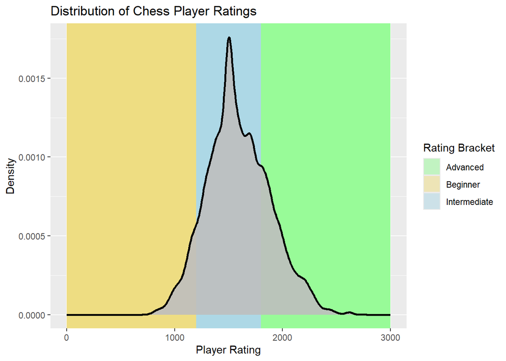

The density plot of chess player ratings reveals a skewed distribution, indicating that the ratings do not follow an approximately normal distribution. While the majority of players cluster around the intermediate rating levels, the shape is asymmetric, with a longer tail extending toward higher ratings.

Next, we examine how the difference in rating between players affects the final match outcome. Rather than using the absolute value of the rating gap, we subtract Black’s rating from White’s. This helps us see not just how big the rating gap is, but also which player had the higher rating, and whether that advantage differs depending on which side of the board they’re on.

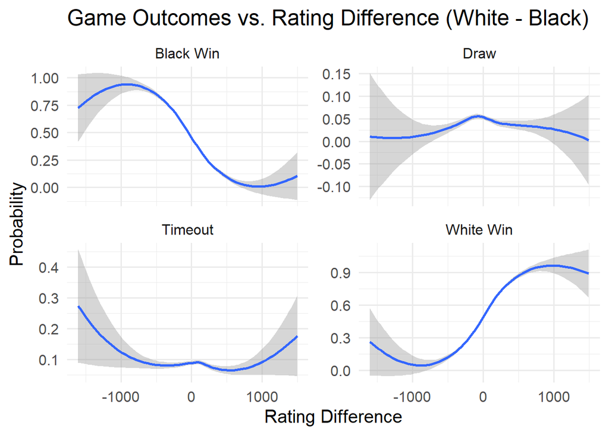

As we see through the black win and White win plots, as rating difference between players increases, the probability of the higher-rated player winning increases. When it comes to a game ending in a draw, draws are most typical when players share similar ratings. Timeout outcomes are most common in games with large rating discrepancies. This data suggests that player rating plays a large role in not only the victor of the game, but the nature of the victory.

**Note:** Even when a game ends in a timeout, a winner is still recorded. A timeout is not equivalent to a draw

We also see a widening on the gray band width among players with large rating difference. This band represents the 95% confidence interval of the regression. This suggests that matches consisting of extreme rating differences are less frequent, resulting in greater uncertainty. In comparison, the lack of gray band width among players of similar ratings suggests a large amount of players who tend to verse others of similar rating.

# Openings Among Player Brackets

Based on the player rating distribution, rating brackets were created starting from the minimum average player rating and increasing in increments of 400 points until the maximum. For each game, the average of the White and Black player ratings was calculated to represent the overall skill level of the match. This method ensures that the brackets accurately reflect the player population, capturing the larger number of lower-rated players while still allowing for meaningful comparisons across skill levels.

Due to the existence of over 1,327 named openings and variations, openings will be grouped by the general terminology and not variation of opening due to the extreme amount of variation titles.

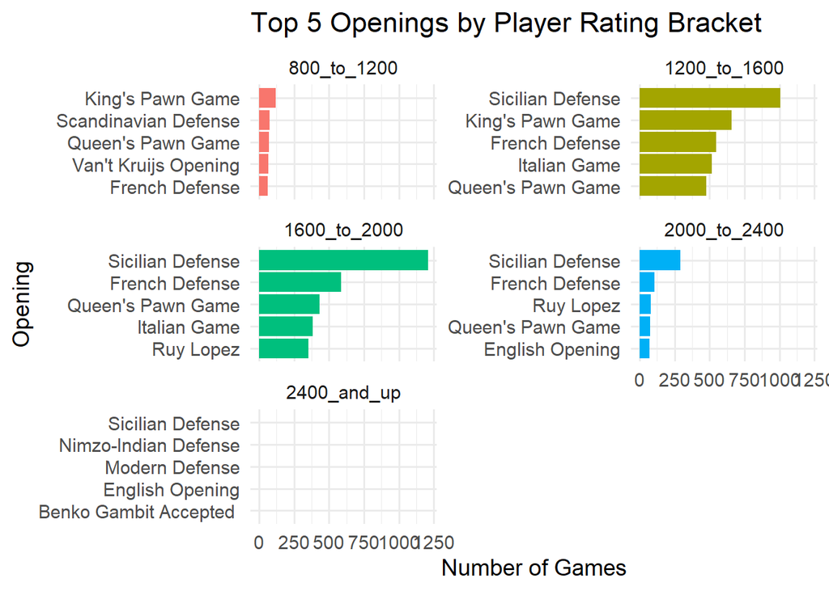

**Note:** the 2400_and_up bracket contains very few players due to its advanced nature, resulting in limited data for opening preferences. The maximum rating among players in this data set falls at 2723. Brackets 0_to_400 and 400_to_800 are not displayed due to an absence of games in those average rating ranges.

We see through these bracket plots that the most popular opening among players of ratings above 1200 is some variation of Sicilian defense. Interestingly, that Sicilian defense does **not** appear as a top opening within players rated under 1200.

According to Chessklub.com, a popular chess blog, Sicilian is considered one of the most complex openings in chess due to the level of variety. The same blog lists King’s Pawns Opening as one of the “Fastest and easiest checkmates.

**Therefore, this data displays not just preference, but the alignment of opening complexity and player skill level.**

# Match Outcome By Opening

Referencing the 5 most popular openings of players of all rankings, this project will now evaluate the distribution of game outcomes. Specifically, it will be looking at winner status (e.g. White win, Black win, draw). This is due to the fact that a timeout game of chess still designates a winner.

First, we evaluate the top 5 chess openings among all players.

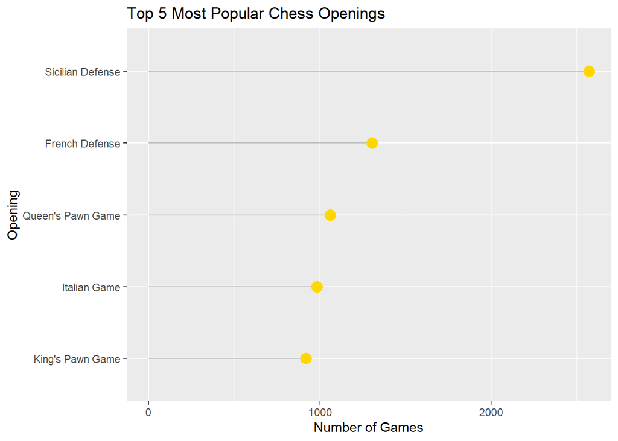

Now using this, we can evaluate the distribution of outcomes among these 5 openings.

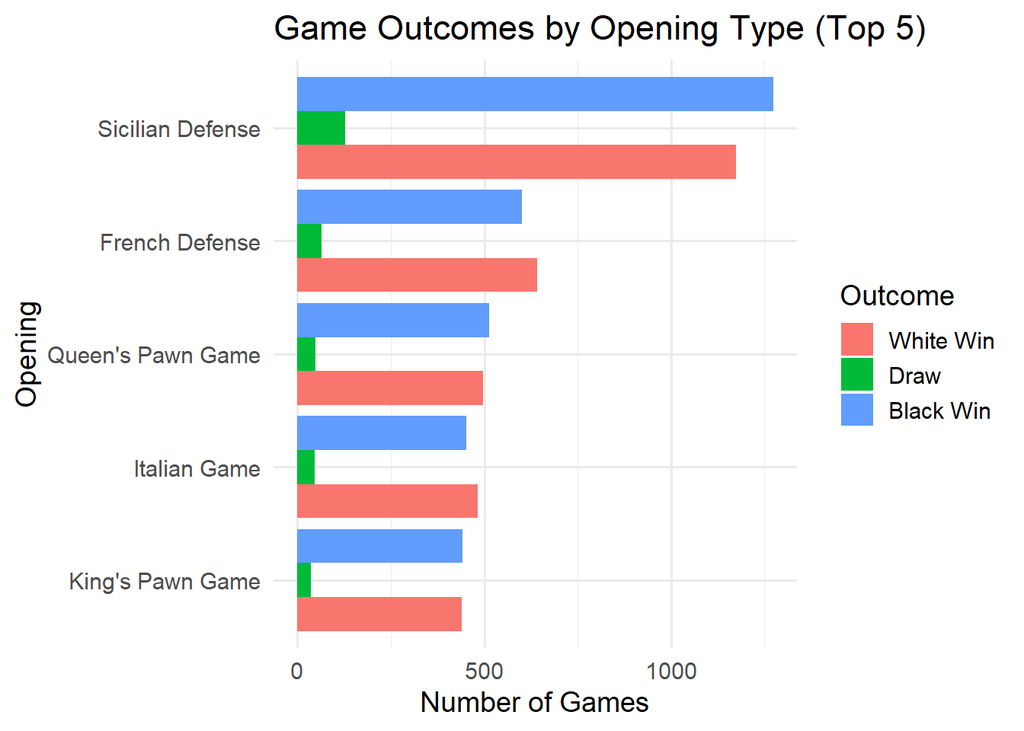

# The First Move

Every chess game begins with White’s first move, which sets the tone for the opening and can shape the overall direction of the game.

In this section, we focus not on full openings, but specifically on White’s very first move to see if it influences who ultimately wins. While there are 20 legal opening moves, we limit our analysis to those used in at least 0.5% of games for clarity.

We’ll first look at the most popular opening moves by White.

**Note**: This data set uses algebraic chess notation, where each piece is represented by a letter (e.g., N = knight). Pawn moves don’t use a letter; for example, e4 means a pawn moved to e4. Since only pawns and knights can move first, this report focuses only on those opening moves.

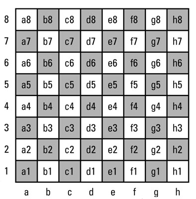

Top 9 Most Common First Moves in Chess Games

| First Move | Number of Games |
| --- | --- |
| e4 | 12598 |
| d4 | 4522 |
| Nf3 | 725 |
| c4 | 716 |
| e3 | 416 |
| g3 | 186 |
| b3 | 173 |
| f4 | 166 |
| d3 | 131 |

This table shows the 9 most popular opening moves by White. The move e4 is shown to be incredibly common, appearing in nearly three times as many games as the next most common move, d4. The move d4 is also seen to greatly exceed the usage of the next most popular move, Nf3.

Both e4 and d4 are central board locations. This poses an interesting question: if central control is the goal, why is e4 played so much more frequently than d4?

To investigate further, we now look at the most efficient first moves in regards to White’s win rate.

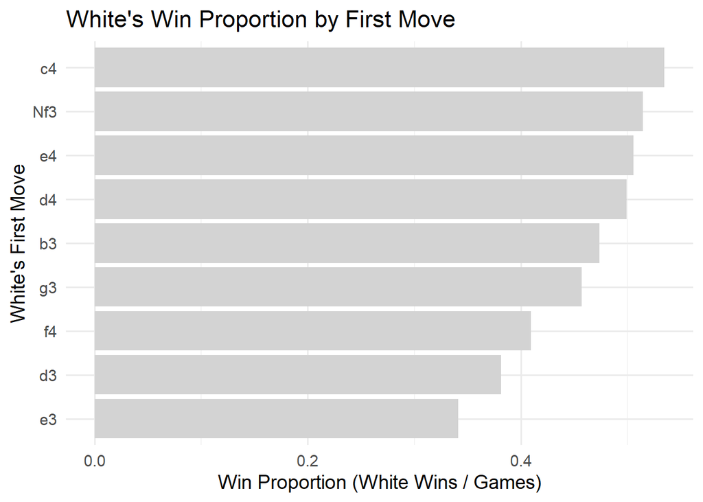

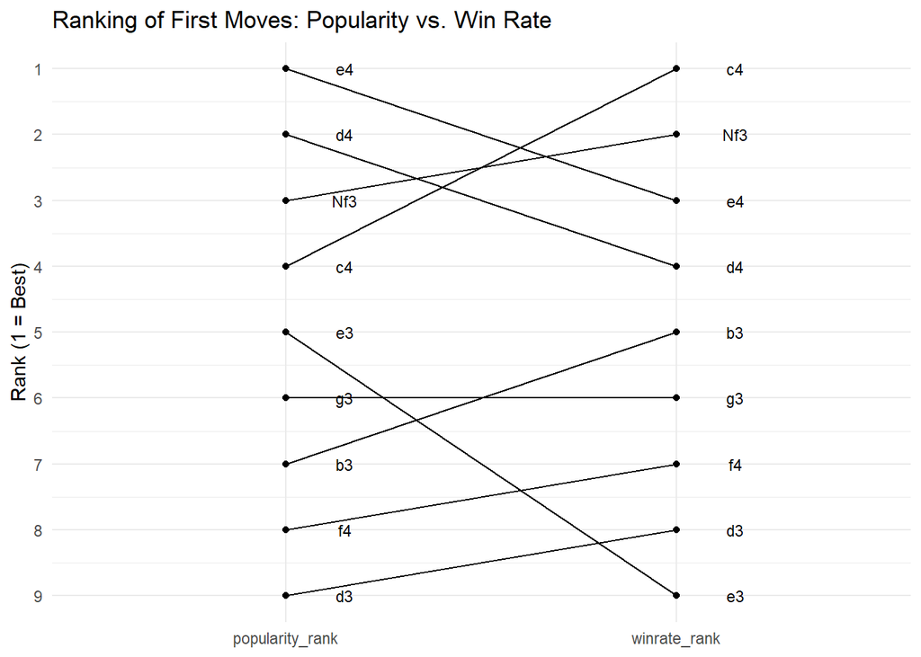

This slope chart visualizes the shift in rank between move popularity and win rate. For example, c4 jumps from 4th in popularity to 1st in win rate, while e3, though mid-ranked in usage, drops to last in effectiveness. These discrepancies highlight that popularity doesn’t always equate to success, further supporting the idea that players that utilize unusual strategy may be at an advantage due to their ability to catch their opponent off guard.

# Black’s Response

Since Black always moves second, win proportions by first move are mirrored: when White wins more often after a certain opening, Black wins less, and vice versa. Additionally, because Black’s first move is a direct response to White’s, analyzing Black’s move in isolation overlooks the context of the position. Therefore, we evaluate game outcomes using White’s opening move as the primary reference point.

In this next section, we explore how Black responds to White’s most efficient opening moves and examine which responses are associated with higher win rates for Black.

First, taking the three most efficient first moves by White, we evaluate the most popular responses by Black.

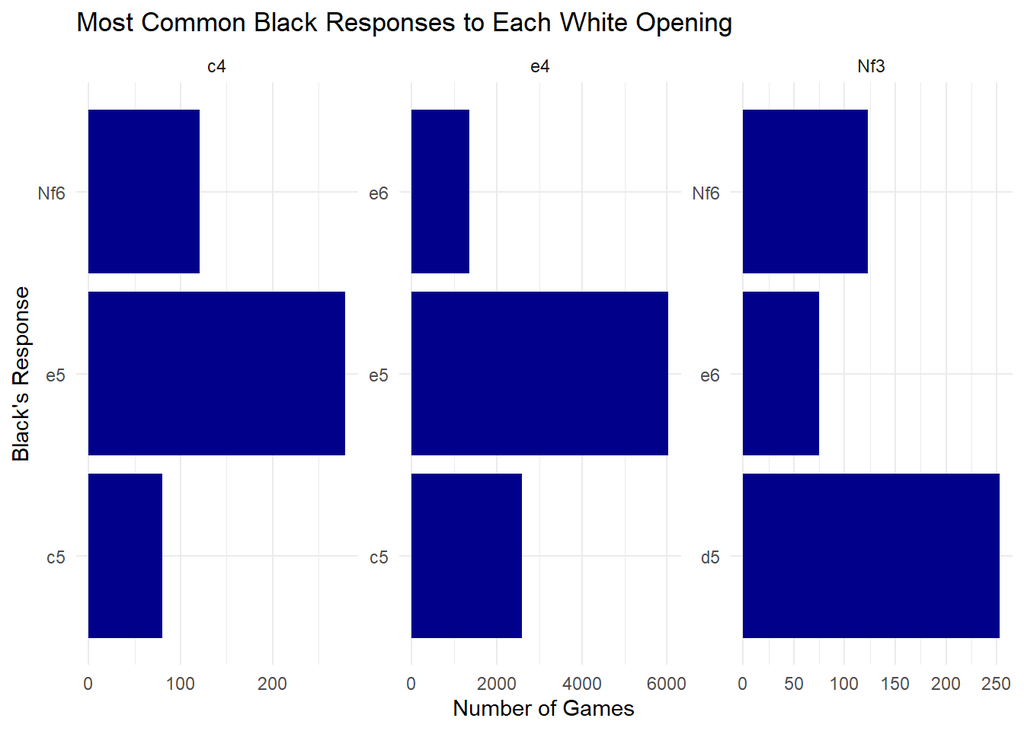

Through this plot, we find that the most common response to c4 is e5, the most common for e4 is e5, and the most common for Nf3 is d5. Now, we can evaluate which responses are not the most populous, but the most effective.

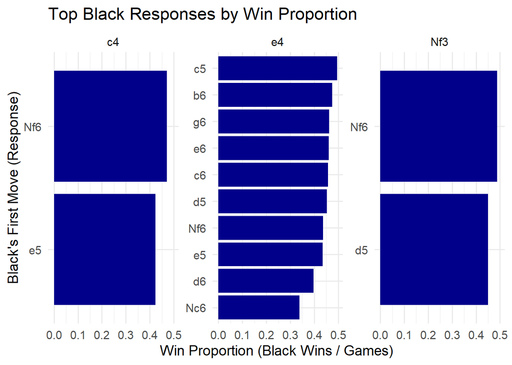

For each of these, we only included responses that appeared in at least 100 games to ensure reliability. Against e4, Black has a wide variety of responses, with c5 leading in effectiveness. In contrast, the openings Nf3 and c4 have far fewer frequent replies, only two for each met the threshold, suggesting either less variation in responses or fewer games overall in the data set. The limited variety also reinforces how standard, popular opening moves tend to dominate.

Interestingly, many of the best-performing responses are not the most popular ones. This further supports the idea that choosing unconventional playing methods may give a player a strategic advantage, likely due to the opponents unfamiliarity.

# Conclusion

In examining the different aspects of chess such as opening, first move, and player rating, we find many telling factors in what can determine the outcome of a chess match. First, we discovered that players with significantly higher ratings tend to win most often, whilst unconventional closes to a match (e.g. draw) tend to occur between players of similar rating.

We then looked into opening sequences, discovering the popularity and effectivity of the sicillian defense. These results demonstrated how as players tend to advance in rating, they deviate to the most effective opening strategy. Similarly, it demonstrated how opening strategies with many different variations such as the Sicillian can benefit players.

Finally, on a smaller scope we looked at the very first move of a chess game rather than opening sequence. Through this data, we established the idea that players that make effective yet uncommon first move choices tend to have better results.

Altogether, this analysis demonstrates how opening strategy, player experience, and move sequences can all influence the outcome of a chess match. This report highlights the great potential of chess game data for deeper pattern discovery.